# s-pneumoniae-serotype-invasiveness

```r
# Load dependencies
require(tidyverse)
require(magrittr)
require(rstan)
require(bridgesampling)
require(loo)
```

```r
require(cowplot)
require(ggrepel)
require(xlsx)
# Load stan package
library(progressionEstimation)
#pkgbuild::compile_dll()
#roxygen2::roxygenize(package.dir = "..")

# Define serotype categories and palettes
vaccine_types <- list(
  "PCV7" = c("4","6B","9V","14","18C","19F","23F"),
  "PCV10" = c("1","5","7F"),
  "PCV13" = c("6A","3","19A"),
  "PCV15" = c("22F","33F"),
  "PCV20" = c("8","10A","11A","12F","15B/C"),
  "PPV23" = c("2","9N","17F","20")
)

vaccine_colours <- c("No PCV" = "blue",
                     "PCV7" = "red",
                     "PCV10" = "orange",
                     "PCV13" = "coral2",
                     "PCV15" = "pink",
                     "PCV20" = "purple",
                     "PPV23" = "black")

epi_colors <- c(
  "carriage" = "skyblue",
  "disease" = "cornflowerblue"
)

model_name_labels <-
  c("null Poisson",
    "null negative binomial",
    "type-specific Poisson",
    "type-specific negative binomial",
    "study-adjusted null Poisson",
    "study-adjusted null negative binomial",
    "study-adjusted type-specific Poisson",
    "study-adjusted type-specific negative binomial"
  )
```

## Description and filtering of the dataset

```r
studies_by_size <-
  S_pneumoniae_infant_serotype %>%
    group_by(study) %>%
    dplyr::mutate(total_count = sum(carriage)+sum(disease)) %>%
    dplyr::select(study,total_count) %>%
    dplyr::distinct() %>%
    dplyr::arrange(desc(total_count)) %>%
    dplyr::select(study) %>%
    dplyr::pull()

S_pneumoniae_infant_serotype %<>%
  dplyr::mutate(study = factor(study, levels = studies_by_size))

full_epi_data_plot <-
  ggplot(S_pneumoniae_infant_serotype %>%
           tidyr::pivot_longer(c(carriage,disease),
                               names_to = "Sample type",
                               values_to = "count"),
         aes(x = study,
             y = count,
             colour = `Sample type`,
             fill = `Sample type`)) +
    geom_col() +
    theme_bw() +
    theme(axis.text.x = element_text(angle = 90, hjust = 1, vjust = 0.5)) +
    scale_fill_manual(values = epi_colors) +
    scale_colour_manual(values = epi_colors)
```

The total number of observations for each serotype can be similarly plotted:

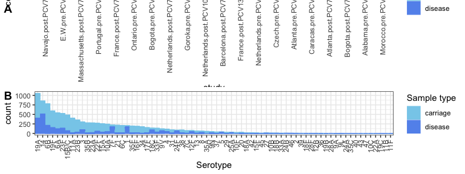

```r
serotype_by_count <-
  S_pneumoniae_infant_serotype %>%
    group_by(type) %>%
    dplyr::mutate(total_count = sum(carriage)+sum(disease)) %>%
    dplyr::select(type,total_count) %>%
    dplyr::distinct() %>%
    dplyr::arrange(desc(total_count)) %>%
    dplyr::select(type) %>%
    dplyr::pull()

S_pneumoniae_infant_serotype %<>%
  dplyr::mutate(type = factor(type, levels = serotype_by_count))

serotype_frequency_plot <-
  ggplot(S_pneumoniae_infant_serotype %>%
           tidyr::pivot_longer(c(carriage,disease),
                               names_to = "Sample type",
                               values_to = "count"),
         aes(x = type,
             y = count,
             colour = `Sample type`,
             fill = `Sample type`)) +
    geom_col() +
    xlab("Serotype") +
    theme_bw() +
    theme(axis.text.x = element_text(angle = 90, hjust = 1, vjust = 0.5)) +
    scale_fill_manual(values = epi_colors) +
    scale_colour_manual(values = epi_colors)

(combined_full_epi_data_plot <-
  cowplot::plot_grid(plotlist = list(full_epi_data_plot, serotype_frequency_plot),
                     nrow = 2,
                     ncol = 1,
                     labels = "AUTO")
)
```

```r
ggsave(combined_full_epi_data_plot,
       file = "full_epi_data_plot.pdf",
       height = 12,
       width = 8
)
```

As many of these serotypes are rare, to facilitate model fitting, we exclude any serotype for which the maximum number of observations is below five:

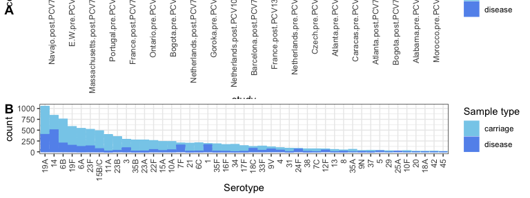

```r
threshold_count <- 5

filtered_S_pneumoniae_infant_serotype <-
  S_pneumoniae_infant_serotype %>%
    dplyr::filter(carriage >= threshold_count | disease >= threshold_count)
# %>%
#     dplyr::group_by(type)%>%
#     dplyr::mutate(study_count = n()) %>%
#     dplyr::ungroup() %>%
#     dplyr::filter(study_count > threshold_count) %>%
#     dplyr::group_by(study) %>%
#     dplyr::mutate(serotype_count = n()) %>%
#     dplyr::ungroup() %>%
#     dplyr::filter(serotype_count > threshold_count) %>%
#     dplyr::mutate(type = factor(type))

filtered_S_pneumoniae_infant_serotype %<>%
    dplyr::mutate(study = factor(study, levels = studies_by_size[studies_by_size %in% unique(filtered_S_pneumoniae_infant_serotype$study)]))

filtered_S_pneumoniae_infant_serotype %<>%
    dplyr::mutate(type = factor(type,
                                          levels = serotype_by_count[serotype_by_count %in% unique(filtered_S_pneumoniae_infant_serotype$type)]))

infant_serotype_invasiveness <-
  progressionEstimation::process_input_data(filtered_S_pneumoniae_infant_serotype)

filtered_epi_data_plot <-
    ggplot(filtered_S_pneumoniae_infant_serotype %>%
           tidyr::pivot_longer(c(carriage,disease),
                               names_to = "Sample type",
                               values_to = "count"),
         aes(x = study,
             y = count,
             colour = `Sample type`,
             fill = `Sample type`)) +
    geom_col() +
    theme_bw() +
    theme(axis.text.x = element_text(angle = 90, hjust = 1, vjust = 0.5)) +
    scale_fill_manual(values = epi_colors) +
    scale_colour_manual(values = epi_colors)

filtered_serotype_frequency_plot <-
  ggplot(filtered_S_pneumoniae_infant_serotype %>%
           tidyr::pivot_longer(c(carriage,disease),
                               names_to = "Sample type",
                               values_to = "count"),
         aes(x = type,
             y = count,
             colour = `Sample type`,
             fill = `Sample type`)) +
    geom_col() +
    xlab("Serotype") +
    theme_bw() +
    theme(axis.text.x = element_text(angle = 90, hjust = 1, vjust = 0.5)) +
    scale_fill_manual(values = epi_colors) +
    scale_colour_manual(values = epi_colors)

(combined_filtered_epi_data_plot <-
  cowplot::plot_grid(plotlist = list(filtered_epi_data_plot, filtered_serotype_frequency_plot),
                     nrow = 2,
                     ncol = 1,
                     labels = "AUTO")
)
```

```r
ggsave(combined_filtered_epi_data_plot,
       file = "filtered_epi_data_plot.pdf",
       height = 12,
       width = 8
)
```

## Fitting the statistical models

The null model, in which each serotype $j$ causes invasive disease at the same rate in each location $i$, can be fitted using a Poisson distribution of disease isolates (**null Poisson** model):

$$d_{i,j} \sim Pois(\nu\rho_{i,j}N_{i}t_{i})$$

The null model can be fitted using a negative binomial distribution of disease isolates (**null negative binomial** model):

$$d_{i,j} \sim NegBin(\nu\rho_{i,j}N_{i}t_{i},\phi)$$

The Poisson model can be modified by allowing each serotype to have its own invasiveness, $\nu_{j}$ (**type-specific Poisson** model):

$$d_{i,j} \sim Pois(\nu_{j}\rho_{i,j}N_{i}t_{i})$$

The negative binomial model can be modified in the same way (**type-specific negative binomial** model):

$$d_{i,j} \sim NegBin(\nu_{j}\rho_{i,j}N_{i}t_{i},\phi)$$

Alternatively, the Poisson model can be modified by allowing invasiveness to be adjusted between locations by a scale factor, $\delta_{i}$. In this model, all serotypes still have the same invasiveness (**adjusted Poisson** model):

$$d_{i,j} \sim Poisson(\delta_{i}\nu\rho_{i,j}N_{i}t_{i})$$

The negative binomial model can again be modified in the same way (**adjusted negative binomial** model):

$$d_{i,j} \sim NegBin(\delta_{i}\nu\rho_{i,j}N_{i}t_{i},\phi)$$

Both modifications can be combined in adjusted type-specific model fits. This can be used with the Poisson model of disease isolate counts (**adjusted type-specific Poisson** model):

$$d_{i,j} \sim Poisson(\delta_{i}\nu_{j}\rho_{i,j}N_{i}t_{i})$$

This can also be used with the negative binomial model (**adjusted type-specific negative binomial** model):

$$d_{i,j} \sim NegBin(\delta_{i}\nu_{j}\rho_{i,j}N_{i}t_{i},\phi)$$

To check the models have fitted correctly, we can plot the $\hat{R}$ values across MCMCs:

```r
fit_list <- list(null_poisson_fit,
                 null_negbin_fit,
                 type_specific_poisson_fit,
                 type_specific_negbin_fit,
                 adjusted_poisson_fit,
                 adjusted_negbin_fit,
                 adjusted_type_specific_poisson_fit,
                 adjusted_type_specific_negbin_fit)

plot_rhat <- function(fit) {
  rhat_plot <- plot(fit, plotfun = "rhat", binwidth = 0.00005) +
                theme(axis.text.x = element_text(angle = 90))
  return(rhat_plot)
}

rhat_plots <- lapply(fit_list, plot_rhat)

combined_rhat_plots <- cowplot::plot_grid(plotlist = rhat_plots, ncol = 4, nrow = 2, labels = "AUTO")



ggsave(combined_rhat_plots,
       file = "infant_combined_rhat_plots.pdf",
       width = 8,
       height = 6)
```

Convergence can also be checked using trace plots of the log likelihood values:

```r
plot_lp <- function(fit) {
  pl <- rstan::traceplot(fit, pars = "lp__")
  no_leg_pl <- pl + theme(legend.position = "none",
                          axis.text.x = element_text(angle = 90))
  return(no_leg_pl)
}

trace_plots <- lapply(fit_list, plot_lp)

combined_trace_plots <- cowplot::plot_grid(plotlist = trace_plots, ncol = 4, nrow = 2, labels = "AUTO")

ggsave(combined_trace_plots,
       file = "infant_combined_trace_plots.pdf",
       width = 8,
       height = 6)
```

## Compare model observations and predictions

For each model, the output can be processed, and the observations plotted against each model’s predictions.

```r
model_outputs <- lapply(fit_list,
                        progressionEstimation::process_progression_rate_model_output,
                        filtered_S_pneumoniae_infant_serotype)

prediction_plots <- lapply(model_outputs,
                           progressionEstimation::plot_case_carrier_predictions,
                           legend = FALSE,
                           n_label = 0)

no_leg_plot <- cowplot::plot_grid(plotlist = prediction_plots,
                                  ncol = 1,
                                  nrow = 8,
                                  labels = "AUTO",
                                  vjust = -0.01) +
      theme(plot.margin = unit(c(0.5,0,0,0), "cm"))

prediction_plot_legend <- progressionEstimation::plot_case_carrier_predictions(model_outputs[[1]], just_legend = TRUE)

pred_v_obs_plot <-
  cowplot::plot_grid(no_leg_plot,
                     prediction_plot_legend,
                     ncol = 1,
                     rel_heights = c(1,0.1))

ggsave(pred_v_obs_plot,
       file = "infant_serotypes_pred_v_obs_plot.pdf",
       height = 20,
       width = 10)
```

The deviation of the predicted and observed values can be simply evaluated using the root mean square error:

[figure not shown]

```r
obs_pred_df <-
  dplyr::bind_rows(model_outputs) %>%
  dplyr::select(model_name,carriage_rmse,disease_rmse,phi,phi_lower,phi_upper) %>%
  tidyr::pivot_longer(c(carriage_rmse,disease_rmse), names_to = "Observation", values_to = "RMSE") %>%
  dplyr::mutate(model_name = factor(model_name,
                                    levels = c(
                                      "null_poisson",
                                      "null_negbin",
                                      "type_specific_poisson",
                                      "type_specific_negbin",
                                      "adjusted_null_poisson",
                                      "adjusted_null_negbin",
                                      "adjusted_type_specific_poisson",
                                      "adjusted_type_specific_negbin"
                                      )
                                    )
                ) %>%
  dplyr::mutate(Observation = dplyr::case_when(
                    Observation == "carriage_rmse" ~ "Carriage",
                    Observation == "disease_rmse" ~ "Disease"
                  )
                )

(serotype_rmse_plot <-
  ggplot(obs_pred_df, aes(x = model_name, y = RMSE)) +
    #geom_boxplot(outlier.shape = NA) +
    geom_point(position = position_jitter(width = 0.25),
               alpha = 0.25,
               cex = 0.75,
               colour = "blue",
               pch = 4) +
    geom_violin(fill = NA) +
    scale_y_continuous(trans="log10") +
    theme_bw() +
    facet_grid(Observation ~ .) +
    scale_x_discrete(labels = model_name_labels) +
    xlab("Model name") +
    theme(axis.text.x = element_text(angle = 90, vjust = 0.5, hjust = 1))
)
```

```r
ggsave(serotype_rmse_plot,
       file = "serotype_rmse_plot.pdf",
       width = 7,
       height = 7
)
```

The fits of the negative binomial can be evaluated through plotting the estimates of the precision parameter, $\phi$. As $\phi$ increases, the variance of the negative binomial distribution decreases, and the negative binomal model becomes more similar to the Poisson model.

[figure not shown]

```r
(phi_plot <-
  ggplot(obs_pred_df %>%
          dplyr::filter(!is.na(phi)) %>%
          dplyr::group_by(model_name) %>%
          dplyr::slice(1) %>%
          dplyr::ungroup(),
        aes(x = model_name,
            y = phi,
            ymin = phi_lower,
            ymax = phi_upper)) +
    geom_point() +
    geom_errorbar(width = 0.25) +
    theme_bw() +
    scale_y_continuous(trans="log10") +
    ylab(expression(phi)) +
    xlab("Model name") +
    scale_x_discrete(labels = model_name_labels[c(2,4,6,8)]) +
    theme(axis.text.x = element_text(angle = 90, vjust = 0.5, hjust = 1))
)
```

```r
ggsave(phi_plot,
       file="serotype_phi_plot.pdf",
       height = 6,
       width = 6)
```

## Run model comparison with leave-one-out cross-validation

The model likelihoods can be compared using leave-one-out cross-validation:

```r
loo_comparison <- progressionEstimation::compare_model_fits_with_loo(fit_list,
                                                                     use_moments = FALSE,
                                                                     num_threads = n_core)







loo_comparison %>%
  kableExtra::kable()  %>%
  kableExtra::kable_styling(latex_options = "scale_down")
```

|  | elpd_diff | se_diff | elpd_loo | se_elpd_loo | p_loo | se_p_loo | looic | se_looic |
| --- | --- | --- | --- | --- | --- | --- | --- | --- |
| adjusted_type_specific_poisson | 0.0000 | 0.00000 | -1780.689 | 33.23288 | 387.4526 | 11.031127 | 3561.378 | 66.46575 |
| adjusted_type_specific_negbin | -13.5003 | 14.55242 | -1794.189 | 25.17121 | 357.1155 | 5.459380 | 3588.379 | 50.34242 |
| type_specific_negbin | -190.5071 | 23.01549 | -1971.196 | 27.92854 | 343.1917 | 5.737811 | 3942.392 | 55.85708 |
| adjusted_null_negbin | -239.4094 | 25.27035 | -2020.098 | 30.52012 | 324.3351 | 5.736621 | 4040.197 | 61.04023 |
| null_negbin | -288.2935 | 24.83839 | -2068.983 | 30.23868 | 299.4660 | 3.162663 | 4137.965 | 60.47737 |
| adjusted_null_poisson | -917.0691 | 111.26184 | -2697.758 | 125.59723 | 457.3265 | 29.991526 | 5395.516 | 251.19446 |
| type_specific_poisson | -950.4216 | 144.79549 | -2731.111 | 158.51865 | 564.7518 | 36.669220 | 5462.221 | 317.03729 |
| null_poisson | -1931.6442 | 223.90635 | -3712.333 | 236.83557 | 311.9120 | 6.839573 | 7424.666 | 473.67113 |

```r
write.csv(loo_comparison,
          file = "child_serotype_loo_comparison.csv",
          quote = FALSE,
          row.names = FALSE)
```

```r
disease_loo_comparison <- progressionEstimation::compare_model_fits_with_loo(fit_list,
                                                                     log_lik_param = "disease_log_lik",
                                                                     use_moments = FALSE,
                                                                     num_threads = n_core)







disease_loo_comparison %>%
  kableExtra::kable()  %>%
  kableExtra::kable_styling(latex_options = "scale_down")
```

|  | elpd_diff | se_diff | elpd_loo | se_elpd_loo | p_loo | se_p_loo | looic | se_looic |
| --- | --- | --- | --- | --- | --- | --- | --- | --- |
| adjusted_type_specific_negbin | 0.00000 | 0.00000 | -762.0105 | 24.36869 | 88.10476 | 5.429932 | 1524.021 | 48.73737 |
| adjusted_type_specific_poisson | -15.25917 | 11.12194 | -777.2696 | 29.14080 | 185.09482 | 13.573559 | 1554.539 | 58.28159 |
| type_specific_negbin | -162.73225 | 12.55451 | -924.7427 | 27.37412 | 57.63924 | 5.081431 | 1849.485 | 54.74825 |
| adjusted_null_negbin | -201.65210 | 15.53140 | -963.6626 | 29.65337 | 46.83912 | 6.993739 | 1927.325 | 59.30675 |
| null_negbin | -253.69192 | 15.42140 | -1015.7024 | 29.41430 | 24.12326 | 4.540623 | 2031.405 | 58.82859 |
| adjusted_null_poisson | -815.04598 | 96.09333 | -1577.0564 | 106.37968 | 551.73939 | 52.174102 | 3154.113 | 212.75936 |
| type_specific_poisson | -825.44431 | 116.26527 | -1587.4548 | 125.20208 | 604.47856 | 64.797459 | 3174.910 | 250.40416 |
| null_poisson | -1741.04324 | 191.89450 | -2503.0537 | 200.99005 | 896.02268 | 82.394407 | 5006.107 | 401.98010 |

```r
write.csv(disease_loo_comparison,
          file = "child_disease_serotype_loo_comparison.csv",
          quote = FALSE,
          row.names = FALSE)
```

## Run model comparison with Bayes factors

As the models can instead be compared with Bayes factors:

```r
bf_comparison <-
  progressionEstimation::compare_model_fits_with_bf(fit_list,
                                                    num_iter = n_iter,
                                                    num_threads = n_core)

bf_comparison %>%
  kableExtra::kable()  %>%
  kableExtra::kable_styling(latex_options = "scale_down")
```

| Model | log_Bayes_factor |
| --- | --- |
| adjusted_type_specific_negbin | 0.00000 |
| adjusted_type_specific_poisson | -30.91517 |
| type_specific_negbin | -96.17864 |
| adjusted_null_negbin | -119.46761 |
| null_negbin | -142.09530 |
| adjusted_null_poisson | -793.66042 |
| type_specific_poisson | -840.98152 |
| null_poisson | -1838.49370 |

```r
write.csv(bf_comparison,
          file = "child_disease_serotype_bf_comparison.csv",
          quote = FALSE,
          row.names = FALSE)
```

## Plot serotype invasiveness

The best-fitting model can then be applied to the overall dataset.

```r
full_infant_serotype_invasiveness <-
  progressionEstimation::process_input_data(
    S_pneumoniae_infant_serotype %<>%
      dplyr::mutate(study = factor(study, levels = studies_by_size)
      )
    )

full_adjusted_type_specific_negbin_fit <-
  progressionEstimation::fit_progression_rate_model(full_infant_serotype_invasiveness,
                                                    type_specific = TRUE,
                                                    location_adjustment = TRUE,
                                                    stat_model = "negbin",
                                                    num_chains = n_chains,
                                                    num_iter = n_iter,
                                                    num_cores = n_core)

rhat_plot <- plot(full_adjusted_type_specific_negbin_fit, plotfun = "rhat", binwidth = 0.00005)

trace_plot <- rstan::traceplot(full_adjusted_type_specific_negbin_fit, pars = "lp__") +
                theme(axis.text.x = element_text(angle = 90))

best_fitting_model_validation_plot <- cowplot::plot_grid(plotlist = list(rhat_plot,trace_plot),
                   nrow = 1,
                   ncol = 2,
                   labels = "AUTO")
ggsave(best_fitting_model_validation_plot,
       file = "best_fitting_infant_model_validation_plot.pdf",
       width = 8,
       height = 6)
```

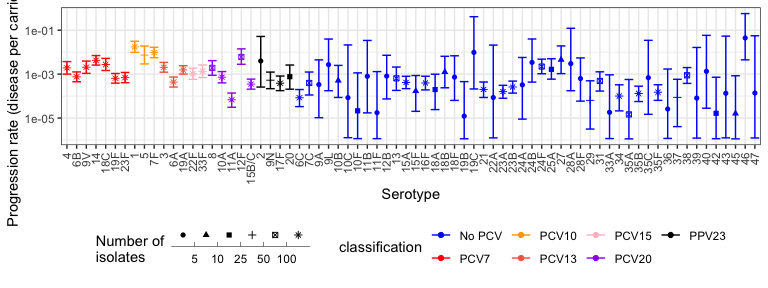

```r
mixedrank = function(x) order(gtools::mixedorder(as.character(x)))

# Annotate serotypes by status
best_fitting_output <-
  progressionEstimation::process_progression_rate_model_output(full_adjusted_type_specific_negbin_fit,
                                                               S_pneumoniae_infant_serotype) %>%
    dplyr::mutate("classification" = dplyr::case_when(
        type %in% vaccine_types[["PCV7"]] ~ "PCV7",
        type %in% vaccine_types[["PCV10"]] ~ "PCV10",
        type %in% vaccine_types[["PCV13"]] ~ "PCV13",
        type %in% vaccine_types[["PCV15"]] ~ "PCV15",
        type %in% vaccine_types[["PCV20"]] ~ "PCV20",
        type %in% vaccine_types[["PPV23"]] ~ "PPV23",
        TRUE ~ "No PCV"
      )
    ) %>%
    dplyr::mutate(classification = factor(classification, levels = c("PCV7",
                                                                     "PCV10",
                                                                     "PCV13",
                                                                     "PCV15",
                                                                     "PCV20",
                                                                     "PPV23",
                                                                     "No PCV")))

# Order serotypes
serotype_levels <-
  best_fitting_output %>%
    dplyr::select(type,classification) %>%
    dplyr::distinct() %>%
    group_by(classification) %>%
    dplyr::arrange(mixedrank(type),
                   .by_group = TRUE) %>%
    ungroup() %>%
    dplyr::select(type) %>%
    dplyr::pull()

best_fitting_output %<>%
  dplyr::mutate(type = factor(type, levels = serotype_levels))

# Plot
(invasiveness_plot <-
  progressionEstimation::plot_progression_rates(best_fitting_output,
                                                unit_time = "year",
                                                type_name = "Serotype",
                                                colour_col = "classification",
                                                colour_palette = vaccine_colours,
                                                use_sample_size = TRUE))
```

```r
ggsave(invasiveness_plot,
       file = "full_serotype_invasiveness_plot.pdf",
       height = 8,
       width = 8)

write.csv(best_fitting_output,
          file = "study_adjusted_type_specific_negbin_serotype_fit.csv",
          quote = F,
          row.names = F)

write.csv(best_fitting_output %>%
            dplyr::select(type,nu,nu_lower,nu_upper) %>%
            dplyr::rename(invasiveness = nu) %>%
            dplyr::rename(invasiveness_lower = nu_lower) %>%
            dplyr::rename(invasiveness_upper = nu_upper) %>%
            dplyr::distinct(),
          file = "Dataset_S1.csv",
          quote = F,
          row.names = F)
```

## Plot study-specific scale factors

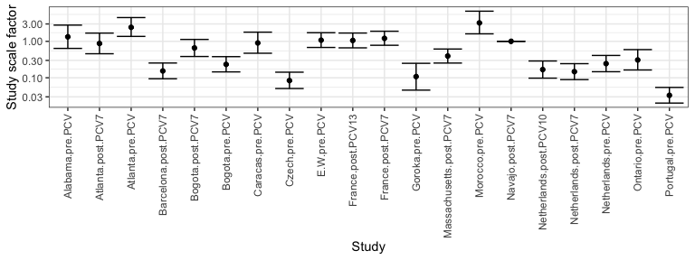

```r
(scale_factor_plot <-
  progressionEstimation::plot_study_scale_factors(best_fitting_output))
```

## Compare a model fit that account for PCVs protecting against disease

If PCVs provide further protection against disease, relative to carriage, then their invasiveness may reduce post-PCV. Therefore we can treat them as different serotypes pre- and post-PCV.

```r
pv_S_pneumoniae_infant_serotype <-
  S_pneumoniae_infant_serotype %>%
    dplyr::mutate(type = dplyr::case_when(
                      type %in% vaccine_types[["PCV7"]] & grepl("post.PCV", study) ~ paste0(type,"_pv"),
                      type == "6A" & grepl("post.PCV", study) ~ paste0(type,"_pv"),
                      type %in% vaccine_types[["PCV10"]] & grepl("post.PCV10", study) ~ paste0(type,"_pv"),
                      type %in% vaccine_types[["PCV10"]] & grepl("post.PCV13", study) ~ paste0(type,"_pv"),
                      type %in% vaccine_types[["PCV13"]] & grepl("post.PCV13", study) ~ paste0(type,"_pv"),
                      type == "6C" & grepl("post.PCV13", study) ~ paste0(type,"_pv"),
                      TRUE ~ as.character(type)
                    )
                  ) %>%
  dplyr::mutate(type = factor(type))

pv_S_pneumoniae_infant_serotype %<>%
  dplyr::mutate(study = factor(study, levels = studies_by_size))

pv_full_infant_serotype_invasiveness <-
  progressionEstimation::process_input_data(pv_S_pneumoniae_infant_serotype)

pv_full_adjusted_type_specific_negbin_fit <-
  progressionEstimation::fit_progression_rate_model(pv_full_infant_serotype_invasiveness,
                                                    type_specific = TRUE,
                                                    location_adjustment = TRUE,
                                                    stat_model = "negbin",
                                                    num_chains = n_chains,
                                                    num_iter = n_iter,
                                                    num_cores = n_core)

rhat_plot <- plot(pv_full_adjusted_type_specific_negbin_fit, plotfun = "rhat", binwidth = 0.00005)

trace_plot <- rstan::traceplot(pv_full_adjusted_type_specific_negbin_fit, pars = "lp__") +
                theme(axis.text.x = element_text(angle = 90, size = 8))

best_fitting_pv_model_validation_plot <-
  cowplot::plot_grid(plotlist = list(rhat_plot,trace_plot),
                   nrow = 1,
                   ncol = 2,
                   labels = "AUTO")
ggsave(best_fitting_pv_model_validation_plot,
       file = "best_fitting_pv_infant_model_validation_plot.pdf",
       width = 8,
       height = 6)
```

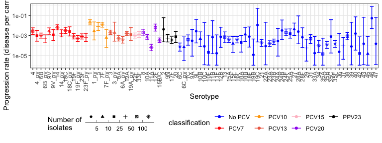

```r
pv_best_fitting_output <-
  progressionEstimation::process_progression_rate_model_output(
    pv_full_adjusted_type_specific_negbin_fit,                                                 pv_S_pneumoniae_infant_serotype) %>%
      dplyr::mutate("classification" = dplyr::case_when(
          gsub("_pv","",type) %in% vaccine_types[["PCV7"]] ~ "PCV7",
          gsub("_pv","",type) %in% vaccine_types[["PCV10"]] ~ "PCV10",
          gsub("_pv","",type) %in% vaccine_types[["PCV13"]] ~ "PCV13",
          gsub("_pv","",type) %in% vaccine_types[["PCV15"]] ~ "PCV15",
          gsub("_pv","",type) %in% vaccine_types[["PCV20"]] ~ "PCV20",
          gsub("_pv","",type) %in% vaccine_types[["PPV23"]] ~ "PPV23",
          TRUE ~ "No PCV"
        )
      ) %>%
      dplyr::mutate(classification = factor(classification, levels = c("PCV7",
                                                                       "PCV10",
                                                                       "PCV13",
                                                                       "PCV15",
                                                                       "PCV20",
                                                                       "PPV23",
                                                                       "No PCV")))

# Order serotypes
pv_serotype_levels <-
  pv_best_fitting_output %>%
    dplyr::select(type,classification) %>%
    dplyr::distinct() %>%
    group_by(classification) %>%
    dplyr::arrange(mixedrank(type),
                   .by_group = TRUE) %>%
    ungroup() %>%
    dplyr::select(type) %>%
    dplyr::pull()

pv_best_fitting_output %<>%
  dplyr::mutate(type = factor(type, levels = pv_serotype_levels))

# Plot
(pv_invasiveness_plot <-
  progressionEstimation::plot_progression_rates(pv_best_fitting_output,
                                                unit_time = "year",
                                                type_name = "Serotype",
                                                colour_col = "classification",
                                                colour_palette = vaccine_colours,
                                                use_sample_size = TRUE))
```

[figure not shown]

```r
(joint_invasiveness_plot <-
    cowplot::plot_grid(plotlist = list(invasiveness_plot + theme(legend.position = "none"), pv_invasiveness_plot),
                       nrow = 2,
                       ncol = 1,
                       rel_heights = c(1,1.2),
                       labels = "AUTO"
                       )
)
```

```r
ggsave(joint_invasiveness_plot,
       file = "joint_infant_serotype_plot.pdf",
       height = 10,
       width = 9)
```

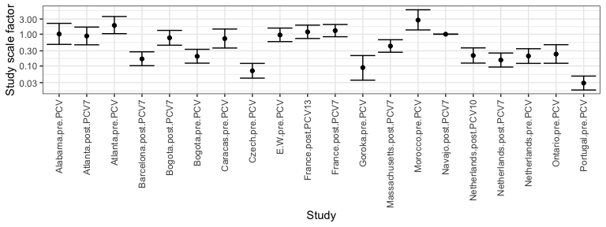

```r
(pv_scale_factor_plot <-
  progressionEstimation::plot_study_scale_factors(pv_best_fitting_output))
```

## Comparison with odds ratio calculation

```r
require(ggpubr)
require(metafor)
```

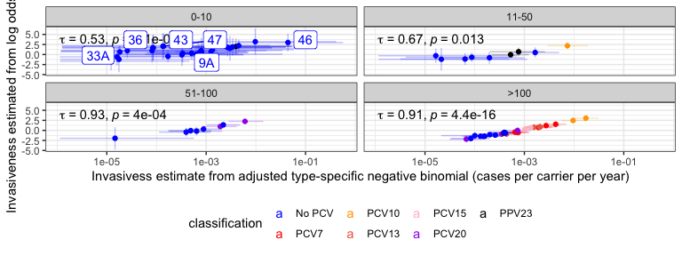

```r
get_serotype_stats <- function(serotype, df) {
  sero_df <-
    df %>%
      tidyr::pivot_longer(c(carriage,disease),
                          names_to = "clinical_manifestation",
                          values_to = "observation") %>%
      dplyr::group_by(study) %>%
      dplyr::mutate(matching_type = dplyr::if_else(type == serotype,1,0)) %>%
      dplyr::mutate(matching_type_disease =
                      sum(observation[clinical_manifestation == "disease" & matching_type == 1])) %>%
      dplyr::mutate(matching_type_carriage =
                      sum(observation[clinical_manifestation == "carriage" & matching_type == 1])) %>%
      dplyr::mutate(non_matching_type_disease =
                      sum(observation[clinical_manifestation == "disease" & matching_type == 0])) %>%
      dplyr::mutate(non_matching_type_carriage =
                      sum(observation[clinical_manifestation == "carriage" & matching_type == 0])) %>%
      dplyr::ungroup() %>%
    dplyr::select(study,matching_type_disease,matching_type_carriage,non_matching_type_disease,non_matching_type_carriage) %>%
    dplyr::distinct() %>%
    dplyr::mutate(serotype = serotype) %>%
    dplyr::filter(matching_type_carriage > 0 | matching_type_disease > 0)
  return(sero_df)
}

per_serotype_estimate <- function(test_serotype, df, method_type = "FE") {
  per_serotype_out <- metafor::rma(yi = yi,
                                   vi = vi,
                                   data = df,
                                   slab = study,
                                   subset = serotype == test_serotype,
                                   method = method_type,
                                   control=list(stepadj=0.5, maxiter=10000))
  summary_df <-
    data.frame(
      "Analysis" = method_type,
      "Serotype" = test_serotype,
      "OR" = as.numeric(per_serotype_out$b),
      "OR_upper" = per_serotype_out$ci.ub,
      "OR_lower" = per_serotype_out$ci.lb,
      "tau_squared" = per_serotype_out$tau2,
      "i_squared" = per_serotype_out$I2,
      "h_squared" = per_serotype_out$H2
    )
  return(summary_df)
}

serotype_or_df <- dplyr::bind_rows(lapply(
                                   serotype_levels,
                                   get_serotype_stats,
                                   S_pneumoniae_infant_serotype)
)

serotype_effect_size_df <- metafor::escalc(measure = "OR",
                                            ai = matching_type_disease,
                                            bi = matching_type_carriage,
                                            ci = non_matching_type_disease,
                                            di = non_matching_type_carriage,
                                            slab = study,
                                            data = serotype_or_df)

per_serotype_out <- dplyr::bind_rows(
                    lapply(
                      serotype_levels,
                      per_serotype_estimate,
                      serotype_effect_size_df
                    ),
                    lapply(
                      serotype_levels,
                      per_serotype_estimate,
                      serotype_effect_size_df,
                      method_type = "REML"
                    )
)

sample_sizes <-
  best_fitting_output %>%
      dplyr::group_by(type) %>%
      dplyr::mutate(num_samples = sum(carriage+disease)) %>%
      dplyr::mutate(Sample_count = dplyr::case_when(
                        num_samples < 11 ~ "0-10",
                        num_samples < 51 ~ "11-50",
                        num_samples < 101 ~ "51-100",
                        TRUE ~ ">100"
                      )
                    ) %>%
      dplyr::ungroup() %>%
      dplyr::select(type, Sample_count) %>%
      dplyr::distinct() %>%
      dplyr::mutate(Sample_count = factor(Sample_count,
                                          levels = c("0-10",
                                                     "11-50",
                                                     "51-100",
                                                     ">100")))

# Combine the invasiveness estimates
combined_invasiveness_df <-
  dplyr::bind_rows(
    per_serotype_out %>%
      dplyr::select(Analysis, Serotype, OR, OR_upper, OR_lower) %>%
      dplyr::rename(Invasiveness = OR) %>%
      dplyr::rename(Invasiveness_upper = OR_upper) %>%
      dplyr::rename(Invasiveness_lower = OR_lower),
    best_fitting_output %>%
      dplyr::select(model_name, nu, nu_lower, nu_upper, type) %>%
      dplyr::distinct() %>%
      dplyr::rename(Analysis = model_name) %>%
      dplyr::rename(Serotype = type) %>%
      dplyr::rename(Invasiveness = nu) %>%
      dplyr::rename(Invasiveness_upper = nu_upper) %>%
      dplyr::rename(Invasiveness_lower = nu_lower)
  ) %>%
  tidyr::pivot_wider(id_cols = Serotype,
                     names_from = Analysis,
                     values_from = c(Invasiveness,Invasiveness_upper,Invasiveness_lower),
                     names_sep = "_") %>%
    dplyr::mutate("classification" = dplyr::case_when(
        Serotype %in% vaccine_types[["PCV7"]] ~ "PCV7",
        Serotype %in% vaccine_types[["PCV10"]] ~ "PCV10",
        Serotype %in% vaccine_types[["PCV13"]] ~ "PCV13",
        Serotype %in% vaccine_types[["PCV15"]] ~ "PCV15",
        Serotype %in% vaccine_types[["PCV20"]] ~ "PCV20",
        Serotype %in% vaccine_types[["PPV23"]] ~ "PPV23",
        TRUE ~ "No PCV"
      )
    ) %>%
  dplyr::left_join(sample_sizes, by = c("Serotype" = "type"))

# Plot comparison of invasiveness estimates
(fixed_effects_comparison <-
  ggplot(combined_invasiveness_df,
       aes(x = Invasiveness_adjusted_type_specific_negbin,
           xmin = Invasiveness_lower_adjusted_type_specific_negbin,
           xmax = Invasiveness_upper_adjusted_type_specific_negbin,
           y = Invasiveness_FE,
           ymin = Invasiveness_lower_FE,
           ymax = Invasiveness_upper_FE,
           colour = classification)) +
  geom_errorbar(alpha = 0.25) +
  geom_errorbarh(alpha = 0.25) +
  geom_point() +
  scale_x_continuous(trans = "log10") +
  theme_bw() +
  scale_color_manual(values = vaccine_colours) +
  theme(legend.position = "bottom") +
  ylab("Invasiveness estimated from log odds ratio") +
  xlab("Invasivess estimate from adjusted type-specific negative binomial (cases per carrier per year)") +
  facet_wrap(~Sample_count) +
  stat_cor(aes(x = Invasiveness_adjusted_type_specific_negbin,
               y = Invasiveness_FE),
           inherit.aes = FALSE,
           method = "kendall",
           cor.coef.name = "tau") +
  ggrepel::geom_label_repel(data = combined_invasiveness_df %>%
                                    dplyr::filter((Invasiveness_adjusted_type_specific_negbin < 0.0005 & Invasiveness_FE > 0) | Serotype == "46"),
                            aes(label = Serotype)
                            )
)
```

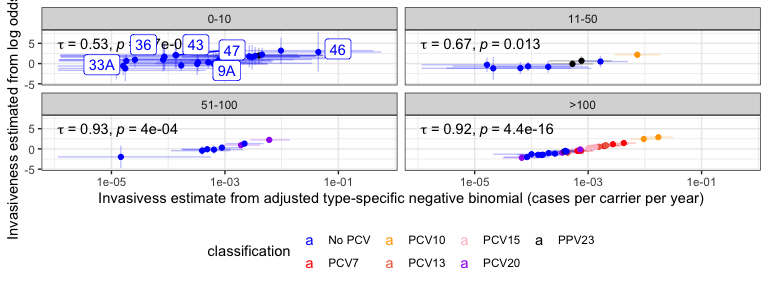

```r
# Plot comparison of invasiveness estimates
(random_effects_comparison <-
  ggplot(combined_invasiveness_df,
         aes(x = Invasiveness_adjusted_type_specific_negbin,
             xmin = Invasiveness_lower_adjusted_type_specific_negbin,
             xmax = Invasiveness_upper_adjusted_type_specific_negbin,
             y = Invasiveness_REML,
             ymin = Invasiveness_lower_REML,
             ymax = Invasiveness_upper_REML,
             colour = classification)) +
    geom_errorbar(alpha = 0.25) +
    geom_errorbarh(alpha = 0.25) +
    geom_point() +
    scale_x_continuous(trans = "log10") +
    theme_bw() +
    scale_color_manual(values = vaccine_colours) +
    theme(legend.position = "bottom") +
    ylab("Invasiveness estimated from log odds ratio") +
    xlab("Invasivess estimate from adjusted type-specific negative binomial (cases per carrier per year)") +
    facet_wrap(~Sample_count) +
    stat_cor(aes(x = Invasiveness_adjusted_type_specific_negbin,
                 y = Invasiveness_REML),
             inherit.aes = FALSE,
             method = "kendall",
             cor.coef.name = "tau") +
    ggrepel::geom_label_repel(data = combined_invasiveness_df %>%
                                      dplyr::filter((Invasiveness_adjusted_type_specific_negbin < 0.0005 & Invasiveness_FE > 0) | Serotype == "46"),
                              aes(label = Serotype)
                              )
)
```

```r
combined_odds_ratio_plot <-
  cowplot::plot_grid(
    plotlist = list(fixed_effects_comparison + theme(legend.position = "none"),
                    random_effects_comparison),
    ncol = 1,
    nrow = 2,
    rel_heights = c(1,1.2),
    labels = "AUTO"
  )

ggsave(combined_odds_ratio_plot,
       file = "combined_odds_ratio_plot.pdf",
       width = 8,
       height = 12)
```

This comparison can be extended to location-specific invasiveness factors, which incorporate the uncertainty of the study-specific adjustment factor:

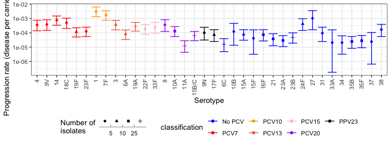

```r
netherland_pre_pcv_invasiveness_df <-
  progressionEstimation::get_type_invasiveness_for_study(S_pneumoniae_infant_serotype,
                         full_adjusted_type_specific_negbin_fit,
                         study = "Netherlands.post.PCV10")

 netherland_pre_pcv_invasiveness_df %<>%
      dplyr::mutate("classification" = dplyr::case_when(
          gsub("_pv","",type) %in% vaccine_types[["PCV7"]] ~ "PCV7",
          gsub("_pv","",type) %in% vaccine_types[["PCV10"]] ~ "PCV10",
          gsub("_pv","",type) %in% vaccine_types[["PCV13"]] ~ "PCV13",
          gsub("_pv","",type) %in% vaccine_types[["PCV15"]] ~ "PCV15",
          gsub("_pv","",type) %in% vaccine_types[["PCV20"]] ~ "PCV20",
          gsub("_pv","",type) %in% vaccine_types[["PPV23"]] ~ "PPV23",
          TRUE ~ "No PCV"
        )
      ) %>%
      dplyr::mutate(classification = factor(classification, levels = c("PCV7",
                                                                       "PCV10",
                                                                       "PCV13",
                                                                       "PCV15",
                                                                       "PCV20",
                                                                       "PPV23",
                                                                       "No PCV")))

# Order serotypes
serotype_levels <-
  netherland_pre_pcv_invasiveness_df %>%
    dplyr::select(type,classification) %>%
    dplyr::distinct() %>%
    group_by(classification) %>%
    dplyr::arrange(mixedrank(type),
                   .by_group = TRUE) %>%
    ungroup() %>%
    dplyr::select(type) %>%
    dplyr::pull()

netherland_pre_pcv_invasiveness_df %<>%
  dplyr::mutate(type = factor(type, levels = serotype_levels))

# Plot
(netherlands_invasiveness_plot <-
  progressionEstimation::plot_progression_rates(netherland_pre_pcv_invasiveness_df,
                                                unit_time = "year",
                                                type_name = "Serotype",
                                                colour_col = "classification",
                                                colour_palette = vaccine_colours,
                                                use_sample_size = TRUE))
```

This subset of serotypes can be compared with the odds ratios estimated using fixed effects:

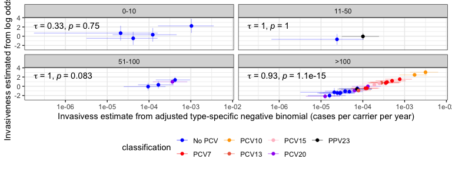

```r
netherlands_or_comparison_df <-
  netherland_pre_pcv_invasiveness_df %>%
                       dplyr::rename(Serotype = type) %>%
                       dplyr::rename(Netherlands_invasiveness = nu) %>%
                       dplyr::rename(Netherlands_invasiveness_lower = nu_lower) %>%
                       dplyr::rename(Netherlands_invasiveness_upper = nu_upper) %>%
                       dplyr::select(-classification) %>%
    dplyr::left_join(combined_invasiveness_df, by = c("Serotype"))

# Plot comparison of invasiveness estimates
(netherlands_fixed_or_comparison_plot <-
  ggplot(netherlands_or_comparison_df,
         aes(x = Netherlands_invasiveness,
             xmin = Netherlands_invasiveness_lower,
             xmax = Netherlands_invasiveness_upper,
             y = Invasiveness_FE,
             ymin = Invasiveness_lower_FE,
             ymax = Invasiveness_upper_FE,
             colour = classification)) +
    geom_errorbar(alpha = 0.25) +
    geom_errorbarh(alpha = 0.25) +
    geom_point() +
    scale_x_continuous(trans = "log10") +
    theme_bw() +
    scale_color_manual(values = vaccine_colours) +
    theme(legend.position = "bottom") +
    ylab("Invasiveness estimated from log odds ratio") +
    xlab("Invasivess estimate from adjusted type-specific negative binomial (cases per carrier per year)") +
    facet_wrap(~Sample_count) +
    stat_cor(aes(x = Invasiveness_adjusted_type_specific_negbin,
                 y = Invasiveness_FE),
             inherit.aes = FALSE,
             method = "kendall",
             cor.coef.name = "tau")
)
```

The same comparison can be undertaken against odds ratios calculated with random effects:

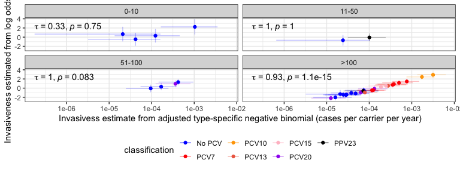

```r
# Plot comparison of invasiveness estimates
(netherlands_random_or_comparison_plot <-
  ggplot(netherlands_or_comparison_df,
         aes(x = Netherlands_invasiveness,
             xmin = Netherlands_invasiveness_lower,
             xmax = Netherlands_invasiveness_upper,
             y = Invasiveness_REML,
             ymin = Invasiveness_lower_REML,
             ymax = Invasiveness_upper_REML,
             colour = classification)) +
    geom_errorbar(alpha = 0.25) +
    geom_errorbarh(alpha = 0.25) +
    geom_point() +
    scale_x_continuous(trans = "log10") +
    theme_bw() +
    scale_color_manual(values = vaccine_colours) +
    theme(legend.position = "bottom") +
    ylab("Invasiveness estimated from log odds ratio") +
    xlab("Invasivess estimate from adjusted type-specific negative binomial (cases per carrier per year)") +
    facet_wrap(~Sample_count) +
    stat_cor(aes(x = Invasiveness_adjusted_type_specific_negbin,
                 y = Invasiveness_REML),
             inherit.aes = FALSE,
             method = "kendall",
             cor.coef.name = "tau")
)
```

```r
combined_netherlands_or_comparison_plot <-
  cowplot::plot_grid(plotlist = list(netherlands_fixed_or_comparison_plot,
                                     netherlands_random_or_comparison_plot),
                     nrow = 1,
                     ncol = 2,
                     labels = "AUTO")

ggsave(combined_netherlands_or_comparison_plot,
       file = "netherlands_or_comparison.pdf",
       height = 8,
       width = 14)
```

## Comparison with carriage duration

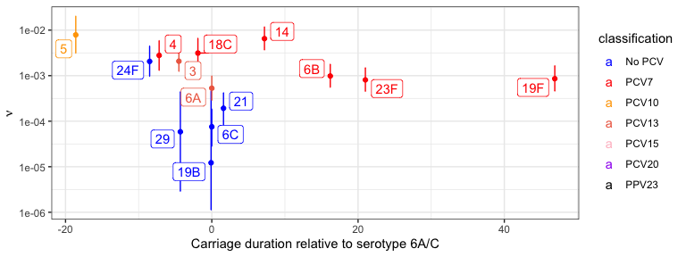

```r
carriage_duration.df <- data.frame(
  "type" = c("19F","23F","6B","14","21","19B","18C","29","3","4","24F","NT","5","6A","6C"),
  "carriage_duration" = c(46.9,21,16.2,7.2,1.6,-0.1,-1.9,-4.3,-4.5,-7.2,-8.5,-12.3,-18.6,0,0)
)

carriage_duration.df %<>%
  dplyr::inner_join(pv_best_fitting_output,
                    by = "type") %>%
  dplyr::select(type,carriage_duration,classification,nu,nu_lower,nu_upper) %>%
  dplyr::distinct()

(invasiveness_v_duration_plot <-
  ggplot(carriage_duration.df,
         aes(x = carriage_duration,
             y = nu,
             ymin = nu_lower,
             ymax = nu_upper,
             colour = classification)) +
    geom_point() +
    geom_errorbar() +
    scale_colour_manual(values = vaccine_colours) +
    ggrepel::geom_label_repel(aes(label = type)) +
    scale_y_continuous(trans = "log10") +
    ylab(expression(nu)) +
    xlab("Carriage duration relative to serotype 6A/C") +
    theme_bw()
)
```

```r
ggsave(invasiveness_v_duration_plot,
       file = "invasiveness_v_duration.pdf",
       height = 8,
       width = 8)
```